# Lab 07 - The Bootstrap

Elyse McCormick

2022-10-26

**Q1 (1 pt.): What is the sample size, n? Show the code you used for the calculation and remember to check for missing data.**

```r
require(palmerpenguins)
dat_pen = droplevels(subset(penguins, species != "Adelie"))
dat_peng = droplevels(subset(dat_pen, species != "Chinstrap"))
n = sum(!is.na(dat_peng$bill_length_mm))
print(n)
```

```
## [1] 123
```

**Q2 (1 pt.): What is the sample standard deviation? Show the code you used for the calculation.**

```r
sd(dat_peng$bill_length_mm, na.rm = TRUE)
```

```
## [1] 3.081857
```

**Q3 (2 pts.): What are the critical t-values? Show the R code you used for the calculation.**

```r
alpha = 0.05
t_crit = abs(qt(alpha / 2, df = n - 1))
print(t_crit)
```

```
## [1] 1.9796
```

**Q4 (1 pt.): What is the sample standard error? Show the R code you used for the calculation.**

```r
sse = sd(dat_peng$bill_length_mm, na.rm = TRUE) / sqrt(n)
print(sse)
```

```
## [1] 0.2778817
```

**Q5 (2 pts.): Finally, construct the CI and show the R code you used for the calculation.**

```r
ci_radius = sse * t_crit
ci = c(
  lower = mean(dat_peng$bill_length_mm, na.rm = TRUE) - ci_radius,
  upper = mean(dat_peng$bill_length_mm, na.rm = TRUE) + ci_radius)
print(round(ci, 4))
```

```
##   lower   upper
## 46.9548 48.0550
```

**Q6 (1 pt.): What is the CI?**

**Q7 (1 pt.): Show the r code you used to call the boot() function.**

```r
require(boot)
boot_mean = function(x, i)
{
  return(mean(x[i], na.rm = TRUE))
}

gentooboot =
  boot(
    data = dat_peng$bill_length_mm,
    statistic = boot_mean,
    R = 10000)
print(gentooboot)
```

```
##
## ORDINARY NONPARAMETRIC BOOTSTRAP
##
##
## Call:
## boot(data = dat_peng$bill_length_mm, statistic = boot_mean, R = 10000)
##
##
## Bootstrap Statistics :
##     original       bias    std. error
## t1* 47.50488 -0.001414535   0.2769779
```

**Q8 (2 pts.): Show the r code you used to calculate the upper and lower 2.5% quantiles.**

```r
quantile(
  gentooboot$t,
  c(0.025, 0.975))
```

```
##     2.5%    97.5%
## 46.96389 48.04684
```

**Q9 (5 pts.): Show your completed rarefaction_sampler() function.**

[output not shown]

**Q10 (1 pt.): What did you find most difficult about building the function?**

Figuring out where the error was.

**Q11 (4 pts.): Show the code you used to perform the simulations and construct the curve.**

```r
# This clears the current R session's environment
rm(list = ls())

# Re-read my data:
require(here)
moths = read.csv(here("data", "moths.csv"))

rarefaction_sampler = function(input_dat, n_iterations)
{
  n_input_rows = nrow(input_dat)

  results_out = matrix(
    nrow = n_iterations,
    ncol = n_input_rows)

  for(i in 1:n_iterations)
  {
       for(j in 1:n_input_rows)
    {
      rows_j = sample(n_input_rows, size = j, replace=TRUE)

      t1 = input_dat[rows_j, ]

      t2 = apply(t1, 2, sum)

      results_out[i, j] = sum(t2 > 0)
    }
  }
  return(results_out)
}

rarefact = rarefaction_sampler(moths[,-1], 100)
head(rarefact)
```

```
##      [,1] [,2] [,3] [,4] [,5] [,6] [,7] [,8] [,9] [,10] [,11] [,12] [,13] [,14]
## [1,]    4    6    9    8   10   10    9   10    9    10     9    10    10    10
## [2,]    2    7    9    9   10   10    8   10   10    10    10     9    10    10
## [3,]    7    8    3    6   10   10    7    9    9    10     9     9    10    10
## [4,]    6    5    7    8   10   10    7    9    8    10     9    10     9    10
## [5,]    2    4    7    7   10    9   10    9    8    10    10     9    10     9
## [6,]    4    5    9    9   10    9    8   10   10    10    10     9     9    10
##      [,15] [,16] [,17] [,18] [,19] [,20] [,21] [,22] [,23] [,24]
## [1,]    10    10    10    10    10    10    10    10    10    10
## [2,]    10    10    10    10    10    10    10    10    10    10
## [3,]     9    10    10    10    10    10    10    10    10    10
## [4,]    10    10    10    10    10    10    10    10    10    10
## [5,]    10     9    10    10    10    10    10    10    10    10
## [6,]    10    10    10    10    10    10    10    10    10     9
```

**Q12 (4 pts.): Include your rarefaction curve plot in your report. Show the R-code you used to create your plot.**

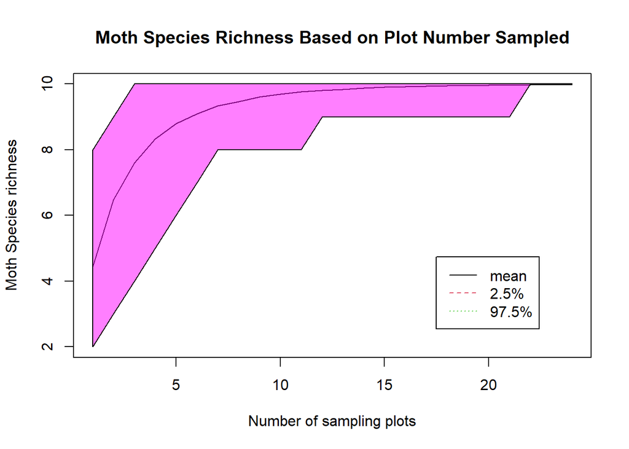

```r
moths = read.csv(here("data", "moths.csv"))
rarefact = rarefaction_sampler(moths[,-1], 10000)

rare_mean = apply(rarefact, 2, mean)
rare_quant = apply(rarefact, 2, quantile, probs=c(0.025, 0.975))
rare = t(rbind(rare_mean, rare_quant))

matplot(
  rare,
  type='l',
  xlab='Number of sampling plots',
  ylab='Moth Species richness',
  main="Moth Species Richness Based on Plot Number Sampled"

  )

legend(
  'bottomright',
  legend=c('mean','2.5%','97.5%'),
  lty=c(1,2,3),col=c(1,2,3), inset=c(.1,.1))


x = c(1:24)

polygon(c(x,rev(x)),c(rare[,3],rev(rare[,2])),col=rgb(1, 0, 1, 0.5))
```

**Q13 (2 pts.): About how many sites should you visit if you want to see all of the moth species? Explain your reasoning using your rarefaction curve figure.**